# Music Retrieval

This notebook presents our implementation of the music identification algorithm used in the original Shazam Paper.

At the end of this notebook, you will find detailed visualizations, evaluations, and a comprehensive discussion of our thought process, results, and conclusions.

## Dataset

The data audio tracks used in this notebook can be found at https://cdn.freesound.org/mtg-jamendo/raw_30s/audio-low/. We used the Tarballs 00-60 for our database creation, which are approxamitely 34,000 tracks. Once downloaded, the Tracks should then be put in the **'tracks/'** directory. The queries to test should be put in the **'queries/'** directory.

### Query Generation

- **Original**: The unmodified 10-second segment.
- **Noise**: The segment with added Gaussian noise.
- **Coding**: A strongly compressed version of the segment.
- **Mobile**: A version recorded outdoors using a mobile phone.

### Data Organization

- **Full Tracks**: Stored in the **'tracks/'** folder.
- **Generated Queries**: Stored in the **'queries/'** folder.

*Note: All audio files are saved in MP3 format*

## Imports

```python
# imports
import os, sys
import numpy as np
from numba import jit
import librosa
#from scipy import signal
from scipy import ndimage
from matplotlib import pyplot as plt
import IPython.display as ipd
import time
import pickle

sys.path.append('..')
import libfmp.b
import libfmp.c2
import libfmp.c6
from IPython.display import clear_output
from collections import defaultdict
import math
import matplotlib.pyplot as plt

%matplotlib inline
```

## Utility functions

In this section, we define all the necessary functions for computing spectrograms, generating constellation maps, calculating hashes, and performing hash matching.

New additions include functions for defining target zones, identifying points within those zones, computing hashes, building the hash database, and matching hashes. We also introduce functions to evaluate the consistency of offsets during the matching process. These new functionalities are central to implementing the audio fingerprinting technique.

```python
def load_filenames(directory):
    filenames = []

    # Iterate through all files in the directory
    for filename in os.listdir(directory):
        # Create the full path
        file_path = os.path.join(directory, filename)

        # Check if it is a file (not a directory)
        if os.path.isfile(file_path):
            # Add to the dictionary, using the filename as the key
            filenames.append(file_path)

    return filenames
```

### Spectrogram

This function is responsible for computing the spectrogram map of a given track. We limit the track duration that is used to 30 seconds.

```python
def compute_spectrogram(fn_wav, Fs=22050, N=2048, H=1024, bin_max=128, frame_max=None, duration=None):
    x, Fs = librosa.load(fn_wav, sr=Fs)
    x_duration = len(x) / Fs
    X = librosa.stft(x, n_fft=N, hop_length=H, win_length=N, window='hann')
    if bin_max is None:
        bin_max = X.shape[0]
    if frame_max is None:
        frame_max = X.shape[0]
    Y = np.abs(X[:bin_max, :frame_max])
    return Y
```

### Constellation map

This function computes the constellation map, given a spectrogram map

```python
def compute_constellation_map(Y, dist_freq=7, dist_time=7, thresh=0.01):
    """Compute constellation map (implementation using image processing)

    Notebook: C7/C7S1_AudioIdentification.ipynb

    Args:
        Y (np.ndarray): Spectrogram (magnitude)
        dist_freq (int): Neighborhood parameter for frequency direction (kappa) (Default value = 7)
        dist_time (int): Neighborhood parameter for time direction (tau) (Default value = 7)
        thresh (float): Threshold parameter for minimal peak magnitude (Default value = 0.01)

    Returns:
        Cmap (np.ndarray): Boolean mask for peak structure (same size as Y)
    """
    result = ndimage.maximum_filter(Y, size=[2*dist_freq+1, 2*dist_time+1], mode='constant')
    Cmap = np.logical_and(Y == result, result > thresh)
    return Cmap
```

```python
from concurrent.futures import ThreadPoolExecutor

def compute_constellation_map_single(args):
    """Compute the constellation map for a single file."""
    filename, dist_freq, dist_time = args
    spectrogram = compute_spectrogram(filename)  # Perform I/O and computation
    constellation_map = compute_constellation_map(spectrogram, dist_freq, dist_time)
    return filename, constellation_map

def compute_constellation_maps(filenames, dist_freq, dist_time):
    """Compute constellation maps using multithreading."""
    # Prepare arguments for each file
    args = [(filename, dist_freq, dist_time) for filename in filenames]

    # Use ThreadPoolExecutor for multithreading
    with ThreadPoolExecutor() as executor:
        results = executor.map(compute_constellation_map_single, args)

    # Convert results to a dictionary
    Cmaps = dict(results)
    return Cmaps
```

```python
count = 0
count2 = 0
hash_count = {}
```

## Computing hashes for a single audio track

This function processes an audio file to compute robust hashes based on its spectrogram.

**Arguments:**

- `filename (str)`: Path to the audio file.
- `dist_freq (int), dist_time (int)`: Neighborhood size parameters for frequency and time directions.
- `time_min_offset, time_max_offset, freq_min_offset, freq_max_offset`: Bounds defining the "target zone" around an anchor point.

**Returns:** A list of tuples `(hash, track_name, time_offset)`:

- `hash`: A unique value based on anchor-target pairs.
- `track_name`: A numeric ID extracted from the filename.
- `time_offset`: The time coordinate of the anchor point.

**Workflow:**

1. **Spectrogram and Constellation Map**: We compute the spectrogram from the audio file and generate a constellation map using the neighborhood parameters.
2. **Sorting Points**: The points are sorted by their time coordinate to make retrieving target zone points more efficient, allowing us to stop the search early when no further points can be within the bounds.
3. **Hash Computation**: For each anchor point, we compute hashes for its target zone points and add them to the result.
4. **Memory Management**: To handle large datasets, we periodically clear memory and print progress after every 1000 tracks.

```python
import gc

def compute_hashes_from_spectrogram(filename, dist_freq=11,
                                    dist_time=3,
                                    time_min_offset=5, time_max_offset=30,
                                    freq_min_offset=-15,
                                    freq_max_offset=15
                                   ):
    """
    Compute hashes for a single track directly from its spectrogram.

    Args:
        filename (str): Path to the audio file.
        dist_freq (int): Neighborhood parameter for frequency direction.
        dist_time (int): Neighborhood parameter for time direction.
        time_min_offset, time_max_offset, freq_min_offset, freq_max_offset (int):
            Bounds for the "target zone" around an anchor point.

    Returns:
        list: [(hash, track_name, time_offset), ...]
    """

    global count
    global count2
    spectrogram = compute_spectrogram(filename)
    cmap = compute_constellation_map(spectrogram, dist_freq, dist_time)

    # Convert the boolean map to a list of points (freq, time), sorted by time
    point_list = sorted(np.argwhere(cmap).tolist(), key=lambda x: x[1])
    hashes = []
    del cmap
    del spectrogram

    for anchor in point_list:
        target_points = get_target_zone_points(
            anchor,
            point_list,
            time_min_offset=time_min_offset,
            time_max_offset=time_max_offset,
            freq_min_offset=freq_min_offset,
            freq_max_offset=freq_max_offset
        )
        for target_point in target_points:
            h = compute_hash(anchor, target_point)
            hashes.append((h, int(extract_numeric_id(filename)), anchor[1]))

    count += 1
    count2 += 1
    if (count % 1000) == 0:
        gc.collect()
        print(f"Processed {count} tracks")

    return hashes
```

## Building our database

The process of constructing the database begins with loading the paths to all audio tracks from a specified directory into memory. The primary goal is to compute unique hash values for each track using audio fingerprinting techniques. To optimize performance and memory management, this process is implemented using multithreading and structured to handle data in manageable chunks.

1. **Track File Loading:**
- The system scans the specified directory to identify all audio files and collects their paths into a list. Each track will later be processed individually.
2. **Parameterized Configuration:**
- The database-building function accepts parameters that define the "constellation map" used for audio fingerprinting. These include:
  - `dist_freq` and `dist_time`: Parameters that control the neighborhood size for identifying key anchor points in the spectrogram.
  - `time_min_offset`, `time_max_offset`: Bounds for the time dimension of the "target zone" around an anchor point.
  - `freq_min_offset`, `freq_max_offset`: Bounds for the frequency dimension of the "target zone."
3. **Multithreaded Processing:**
- A thread pool is created to process multiple audio tracks in parallel. Each thread:
  - Reads a track's spectrogram.
  - Computes hash values based on anchor points and their surrounding "target zones."
  - Returns a list of hashes along with the track's name and time offsets for each hash.
4. **Chunk-Based Memory Management:**
- To prevent excessive memory usage, the computed hashes are not stored indefinitely in memory. Instead:
  - Once hashes for approximately 1000 tracks are accumulated, they are written to a partial database file on the hard drive.
  - This partial database is stored in a single file with a name derived from the configuration parameters (e.g., partial_database_11#3#5#30#-15#15.pkl).
5. **Final Consolidation:**
- After all tracks are processed, any remaining hashes are written to the same partial database file. This ensures that all computed hashes are consolidated into a single, organized file.
6. **Return and Cleanup:**
- The function clears the in-memory database after saving it to disk to free up space again.

```python
def build_database(
    directory,
    dist_freq=11,
    dist_time=3,
    time_min_offset=5,
    time_max_offset=30,
    freq_min_offset=-15,
    freq_max_offset=15
):
    global count
    count = 0
    config_name = f"hash_count_freq{dist_freq}_time{dist_time}_min{time_min_offset}_max{time_max_offset}_{freq_min_offset}_{freq_max_offset}"
    hash_count[config_name] = 0

    """
    Build a fingerprint database directly from spectrograms using multithreading.

    Args:
        directory (str): Directory containing audio files.
        dist_freq, dist_time (int): Constellation map neighborhood parameters.
        time_min_offset, time_max_offset, freq_min_offset, freq_max_offset (int):
            Bounds for the "target zone" around an anchor point.

    Returns:
        database (defaultdict): {hash: [(track_name, time_offset), ...]}
    """
    tracks = load_filenames(directory)

    path_name = "partial_database_" + str(dist_freq) + "#" + str(dist_time) + "#" + str(time_min_offset) + "#" + str(time_max_offset) + "#" + str(freq_min_offset) + "#" + str(freq_max_offset) + ".pkl"

    # Prepare arguments for each file
    args = [
        (filename, dist_freq, dist_time, time_min_offset, time_max_offset, freq_min_offset, freq_max_offset)
        for filename in tracks
    ]

    database = defaultdict(list)
    global count2

    # Use multithreading to compute hashes for all tracks
    with ThreadPoolExecutor() as executor:
        for result in executor.map(lambda x: compute_hashes_from_spectrogram(*x), args):
            hash_count[config_name] += len(result)
            for h, track_name, time_offset in result:
                database[h].append((track_name, time_offset))
                hash_count[config_name] += 1
            if(count2 > 1000):
                count2 = 0
                save_partial_database(database, path_name)
                database.clear()

    save_partial_database(database, path_name)
    database.clear()
    return database
```

## Hash function

This function computes a 32-bit hash, capturing the relationship between an anchor point and a single point within the target zone. The hashing process follows the methodology outlined in the lectures and the Shazam paper, ensuring the hash fits within 32 bits for efficient storage and matching.

```python
def compute_hash(anchor, target):
    """Generate a 32-bit hash."""
    f1, t1 = anchor
    f2, t2 = target
    dt = t2 - t1
    return (f1 & 0x3FF) | ((f2 & 0x3FF) << 10) | ((dt & 0xFFF) << 20)
```

## Target zone

This function identifies and selects points within the target zone of a given anchor point. It determines which points (peaks) from the constellation map fall within the specified bounds and returns all points that meet this criterion. For improved efficiency in identifying points within the target zone, the input point_list is expected to be sorted by time. This sorting allows the function to terminate early when encountering points that are too far in the future.

```python
def get_target_zone_points(anchor, point_list,
                           time_min_offset, time_max_offset,
                           freq_min_offset, freq_max_offset):
    """
    Finds points in 'point_list' that lie within time [t1 + time_min_offset, t1 + time_max_offset]
    and frequency [f1 + freq_min_offset, f1 + freq_max_offset].

    anchor: (f1, t1) or (t1, f1) – whichever convention you are using.
    point_list: list of (f, t) or (t, f) – must be sorted by the time coordinate as we want to break early.
    time_min_offset, time_max_offset: how far in time we look relative to anchor's time t1.
    freq_min_offset, freq_max_offset: how far in frequency we look relative to anchor's freq f1.
    """
    f1, t1 = anchor

    # Time bounds
    t_min = t1 + time_min_offset
    t_max = t1 + time_max_offset

    # Frequency bounds
    f_min = f1 + freq_min_offset
    f_max = f1 + freq_max_offset

    target_zone_points = []
    for (f2, t2) in point_list:
        # If the list is sorted by time and t2 > t_max, we can break early.
        if t2 > t_max:
            break

        if t_min < t2 <= t_max and f_min <= f2 <= f_max:
            target_zone_points.append((f2, t2))

    return target_zone_points
```

## Extract id from filename

Simple helper functions to extract the id and type of from filename.

```python
import re
import random

def extract_numeric_id(filename):
    match = re.search(r'(\d+)', filename)
    return match.group(1) if match else None
```

```python
def extract_query_type(filename):
    match = re.search(r"queries/\d+_(.*)\.mp3", filename)
    return match.group(1) if match else None
```

## Retrieving Accuracy for evaluation

Simple hepler function used for the evaluation part of the notebook.

```python
def get_accuracy(queries, bestmatches):
    match_count = 0
    original_count = 0
    noise_count = 0
    coding_count = 0
    mobile_count = 0

    for query_name in queries:
            track_id, _, _, _, d = bestmatches[query_name]  # Unpack values, d is the time
            is_match = int(extract_numeric_id(query_name)) == track_id  # Check if IDs match
            if is_match:
                match_count += 1

                # for type accuracy
                query_type = extract_query_type(query_name)
                if query_type == 'original':
                    original_count += 1
                elif query_type == 'noise':
                    noise_count += 1
                elif query_type == 'coding':
                    coding_count += 1
                elif query_type == 'mobile':
                    mobile_count += 1


    N = len(queries)
    return { "total": match_count / N,
            "original": original_count / (N/4),
            "noise": noise_count / (N/4),
            "coding": coding_count / (N/4),
            "mobile": mobile_count / (N/4)
           }
```

## Matching a single query

In this implementation, we created a function, find_best_match_for_query, to match a single query audio track against a database of audio fingerprints. Following the method outlined in the Shazam paper for audio fingerprinting, we utilized a combination of hashing and offset analysis to identify the most likely match. Here's what we did step-by-step:

1. **Extract Query Features**: We started by converting the spectrogram of the query track (represented as a 2D Boolean array, cmap) into a list of (frequency, time) points where the spectrogram is non-zero. These points represent prominent features in the audio.
2. **Target Zone Generation**: For each anchor point in the query, we defined a "target zone" in the spectrogram, constrained by frequency and time offsets (time_min_offset, time_max_offset, freq_min_offset, and freq_max_offset). This allowed us to identify significant relationships between anchor points and their neighbors.
3. **Hash Calculation**: We generated unique hashes for pairs of anchor and target points in the query. These hashes encapsulate the relationship between points in terms of time and frequency, enabling robust matching against the database.
4. **Database Lookup**: For each hash, we checked if it exists in the database. If found, we retrieved the corresponding track and time offset information from the database. This step is crucial as it allows us to correlate features in the query with precomputed features in the database.
5. **Offset Analysis**: We grouped the matches by track name and analyzed their time offsets (delta values between query points and database points). For each track, we tracked how many points matched at the same delta offset, which is a key indicator of a correct match.
6. **Best Match Identification**: Finally, we identified the track with the highest number of consistent matches (i.e., the highest count of points matching at the same offset). This track was returned as the best match, along with the corresponding offset and match count.

```python
def find_best_match_for_query(
    query_name,
    cmap,
    database,
    time_min_offset=5,
    time_max_offset=30,
    freq_min_offset=-15,
    freq_max_offset=15
):
    """
    Given a query's spectrogram cmap (2D Boolean array),
    find the best matching track in the database of fingerprints.

    Returns:
        best_track: str or None
        best_delta: int or None
        best_count: int
        point_list: list of non-zero (freq,time) points in the query
    """
    # Convert the boolean array to a list of points (freq, time)
    point_list = sorted(np.argwhere(cmap).tolist(), key=lambda x: x[1])

    # Dictionary of track_name -> (offset -> count)
    matches = defaultdict(lambda: defaultdict(int))

    # For each point in the query, find matching points in the database
    for anchor in point_list:
        target_points = get_target_zone_points(
            anchor,
            point_list,
            time_min_offset=time_min_offset,
            time_max_offset=time_max_offset,
            freq_min_offset=freq_min_offset,
            freq_max_offset=freq_max_offset
        )

        for target_point in target_points:
            h = compute_hash(anchor, target_point)

            # If our hash is found in the database
            if h in database:
                # database[h] = list of (track_name, track_offset)
                for track_name, track_offset in database[h]:
                    delta_offset = track_offset - anchor[1]
                    matches[track_name][delta_offset] += 1

    # Find the best match with the highest count
    best_track = None
    best_delta = None
    best_count = 0

    for track_name, offset_counts in matches.items():
        for delta_offset, count in offset_counts.items():
            if count > best_count:
                best_count = count
                best_track = track_name
                best_delta = delta_offset

    return best_track, best_delta, best_count, point_list
```

## Matching all queries

In this process, we match query audio files against a database that is loaded incrementally in chunks from a serialized file. This chunk-wise processing approach ensures efficient memory usage, as we avoid the need to load the entire database into memory at once. Instead, we process smaller, manageable portions of the database, allowing us to achieve better performance, especially when working with large datasets.

### Process Breakdown

1. **Query Loading:**
- We load all the query file paths from the specified directory into memory.
- For each query, we compute its corresponding "constellation map," which represents key features of the audio file, and it will be used to match against the database.
2. **Incremental Database Loading:**
- The database is loaded in chunks using the load_partial_database function. Each chunk contains a subset of the precomputed hashes stored in the database file.
- By processing one chunk at a time, we keep memory usage efficient and prevent overloading the system with large datasets.
3. **Matching Queries to Database Chunks:**
- For each query, we attempt to find the best match in the current database chunk:
  - **Comparison:** We compare the precomputed constellation map of the query against the hashes in the database chunk.
  - **Scoring:** The find_best_match_for_query function helps us identify the best-matching track, time offset, and match count based on the query's features.
- We keep track of the best match for each query, updating it if a better match (higher match count) is found in a chunk.
- The time taken to process each query is also recorded and accumulated.
4. **Result Consolidation:**
- After processing all chunks, we compile the best matches for each query, along with the corresponding time offsets and processing durations.
5. **Result Evaluation:**
- For each query, we compare the best-matching track ID with the expected track ID (extracted from the query filename). A match is correct if the IDs align.
- We calculate:
  - The total number of correct matches (count3).
  - The total and average processing time for all queries.
- We print the results for each query, including the match status and processing time.
6. **Return:**
- Finally, we return the bestmatches dictionary, which contains detailed match results for all queries. This information is useful for us in the evaluation phase.

```python
def match_queries_with_chunks(
    directory,
    dist_freq=11,
    dist_time=3,
    time_min_offset=5,
    time_max_offset=30,
    freq_min_offset=-15,
    freq_max_offset=15
):
    """
    Match queries against a database loaded incrementally in chunks.

    Args:
        directory (str): Path to the query files.
        database_file (str): Path to the serialized database file.
        time_min_offset, time_max_offset, freq_min_offset, freq_max_offset (int):
            Bounds for matching.

    Returns:
        results (list): List of query match results.
    """
    database_file = "partial_database_" + str(dist_freq) + "#" + str(dist_time) + "#" + str(time_min_offset) + "#" + str(time_max_offset) + "#" + str(freq_min_offset) + "#" + str(freq_max_offset) + ".pkl"
    queries = load_filenames(directory)  # Load all query filenames
    results = []
    num_correct = 0
    total_queries = len(queries)

    cmaps = {}

    for query_name in queries:
        _, cmap = compute_constellation_map_single((query_name, 11, 3))
        cmaps[query_name]=cmap

    bestmatches = {}
    for database_chunk in load_partial_database(database_file):
        for query_name in queries:
            start = time.time()
            track, delta, count, points = find_best_match_for_query(
                query_name,
                cmaps[query_name],
                database_chunk,
                time_min_offset=time_min_offset,
                time_max_offset=time_max_offset,
                freq_min_offset=freq_min_offset,
                freq_max_offset=freq_max_offset
            )
            if query_name in bestmatches:
                if bestmatches[query_name][2] < count:
                    end = time.time()
                    d = (end - start) * 1000
                    d = d + bestmatches[query_name][4]
                    bestmatches[query_name] = track, delta, count, points, d
                else:
                    end = time.time()
                    d = (end - start) * 1000
                    d = d + bestmatches[query_name][4]
                    track, delta, count, points, _ = bestmatches[query_name]
                    bestmatches[query_name] = track, delta, count, points, d
            else:
                end = time.time()
                d = (end - start) * 1000
                bestmatches[query_name] = track, delta, count, points, d



    # Print final results
    count3 = 0
    total_time = 0.0  # To accumulate the total time
    time_count = 0  # To count the number of time values

    for query_name in queries:
        track_id, _, _, _, d = bestmatches[query_name]  # Unpack values, d is the time
        is_match = int(extract_numeric_id(query_name)) == track_id  # Check if IDs match

        # Extract numeric time from string (e.g., "1.23s" -> 1.23)
        total_time += d  # Add to total time
        time_count += 1  # Increment the count for time

        if is_match:
            count3 += 1
        # Print query, track ID, match status, and time
        print(f"Query: {query_name}, Track ID: {track_id}, Match: {is_match}, Time: {d}")

    # Calculate the average time
    average_time = total_time / time_count if time_count > 0 else 0

    # Print the final count and average time
    print(f"Matches: {count3}/80")
    print(f"Average Time: {average_time:.2f}ms")

    return bestmatches
```

## Load Database incrementally

This function, `load_partial_database`, loads chunks of data from a pickle file incrementally. Instead of loading the entire file into memory, it yields one chunk at a time, allowing for efficient memory usage. This approach is particularly useful for processing large datasets, as it enables step-by-step iteration through the chunks in a loop, as demonstrated in the `match_queries_with_chunks` function. By yielding each chunk, the function ensures that only the currently needed portion of the database is loaded into memory, optimizing performance.

```python
def load_partial_database(filename):
    """Load chunks from a pickle file incrementally."""
    with open(filename, "rb") as f:
        while True:
            try:
                yield pickle.load(f)  # Yield one chunk at a time
            except EOFError:
                break  # Stop when end of file is reached
```

## Save Database incrementally

The `save_partial_database` function appends a given database to a specified file. By using append mode (`"ab"`), it ensures that the new data is added to the existing file without overwriting its current contents. This method is particularly useful for storing partial chunks of data incrementally, allowing the database to grow dynamically while preserving previously saved chunks.

```python
def save_partial_database(database, filename):
    """Append partial data to a pickle file."""
    with open(filename, "ab") as f:  # Append mode
        pickle.dump(database, f)
```

# Task 1

In the earlier sections, we explained many of the helper functions used in this implementation. Here, we focus on executing these functions effectively within our matching process.

Now, we define **four new configurations for the target zone parameters**. These configurations were tested extensively, first on a small dataset to fine-tune the parameters, and later scaled up to evaluate performance on a larger dataset of 60 tarballs.

When defining the target zones, the size of the zone plays a critical role. Larger zones result in more hashes being computed for each track, which increases memory usage, processing time, and query-matching overhead. To balance these trade-offs, we opted for smaller target zones, which provide efficient matching without significantly compromising accuracy.

## Define configurations

```python
config_1 = {
    "time_min_offset": 0,
    "time_max_offset": 50,
    "freq_min_offset": -10,
    "freq_max_offset": 30
}

config_2 = {
    "time_min_offset": 0,
    "time_max_offset": 30,
    "freq_min_offset": 0,
    "freq_max_offset": 25
}

config_3 = {
    "time_min_offset": 10,
    "time_max_offset": 40,
    "freq_min_offset": -20,
    "freq_max_offset": 20
}

config_4 = {
    "time_min_offset": 10,
    "time_max_offset": 40,
    "freq_min_offset": -30,
    "freq_max_offset": 30
}

configs = [config_1, config_2, config_3, config_4]
```

## Build the database

In this section, we construct the databases required for our audio identification system. The dataset consists of 60 tarballs containing approximately 33,000 tracks. We build a separate database for each of the four target zone configurations defined earlier.

To improve efficiency and avoid recalculating the database and hashes each time we run this notebook, we save the constructed databases to binary files using pickle. This ensures persistence while allowing us to reuse the databases seamlessly in subsequent runs.

For a detailed explanation of the build_database function and its implementation, refer to the earlier section where it is defined.

By creating distinct databases for each configuration, we can experiment with and evaluate the impact of different target zone parameters on performance, accuracy, and scalability.

```python
s = time.time()
database_1 = build_database("tracks", **config_1)
e = time.time()
delta1 = e-s
```

```
Processed 1000 tracks
Processed 2000 tracks
Processed 3000 tracks
Processed 4000 tracks
Processed 5000 tracks
Processed 6000 tracks
Processed 7000 tracks
Processed 8000 tracks
Processed 9000 tracks
Processed 10000 tracks
Processed 11000 tracks
Processed 12000 tracks
Processed 13000 tracks
Processed 14000 tracks
Processed 15000 tracks
Processed 16000 tracks
Processed 17000 tracks
Processed 18000 tracks
Processed 19000 tracks
Processed 20000 tracks
Processed 21000 tracks
Processed 22000 tracks
Processed 23000 tracks
Processed 24000 tracks
Processed 25000 tracks
Processed 26000 tracks
Processed 27000 tracks
Processed 28000 tracks
Processed 29000 tracks
Processed 30001 tracks
Processed 31000 tracks
Processed 32000 tracks
Processed 33000 tracks
```

```python
s = time.time()
database_2 = build_database("tracks", **config_2)
e = time.time()
delta2 = e-s
```

```
Processed 1000 tracks
Processed 2000 tracks
Processed 3000 tracks
Processed 4000 tracks
Processed 5000 tracks
Processed 6000 tracks
Processed 7000 tracks
Processed 8000 tracks
Processed 9000 tracks
Processed 10000 tracks
Processed 11000 tracks
Processed 12000 tracks
Processed 13000 tracks
Processed 14001 tracks
Processed 15000 tracks
Processed 16000 tracks
Processed 17000 tracks
Processed 18000 tracks
Processed 19000 tracks
Processed 20000 tracks
Processed 21000 tracks
Processed 22000 tracks
Processed 23000 tracks
Processed 24000 tracks
Processed 25000 tracks
Processed 26000 tracks
Processed 27000 tracks
Processed 28000 tracks
Processed 29000 tracks
Processed 30000 tracks
Processed 31000 tracks
Processed 32000 tracks
Processed 33000 tracks
```

```python
s = time.time()
database_3 = build_database("tracks", **config_3)
e = time.time()
delta3 = e-s
```

```
Processed 1000 tracks
Processed 2000 tracks
Processed 3000 tracks
Processed 4000 tracks
Processed 5000 tracks
Processed 6000 tracks
Processed 7000 tracks
Processed 8000 tracks
Processed 9000 tracks
Processed 10000 tracks
Processed 11001 tracks
Processed 12000 tracks
Processed 13000 tracks
Processed 14000 tracks
Processed 15000 tracks
Processed 16000 tracks
Processed 17000 tracks
Processed 18000 tracks
Processed 19000 tracks
Processed 20000 tracks
Processed 21000 tracks
Processed 22000 tracks
Processed 23000 tracks
Processed 24000 tracks
Processed 25000 tracks
Processed 26000 tracks
Processed 27000 tracks
Processed 28000 tracks
Processed 29000 tracks
Processed 30000 tracks
Processed 31000 tracks
Processed 32000 tracks
Processed 33000 tracks
```

```python
s = time.time()
database_4 = build_database("tracks", **config_4)
e = time.time()
delta4 = e-s
```

```
Processed 1000 tracks
Processed 2000 tracks
Processed 3000 tracks
Processed 4000 tracks
Processed 5000 tracks
Processed 6000 tracks
Processed 7000 tracks
Processed 8000 tracks
Processed 9000 tracks
Processed 10000 tracks
Processed 11000 tracks
Processed 12000 tracks
Processed 13000 tracks
Processed 14000 tracks
Processed 15000 tracks
Processed 16000 tracks
Processed 17000 tracks
Processed 18000 tracks
Processed 19000 tracks
Processed 20000 tracks
Processed 21000 tracks
Processed 22000 tracks
Processed 23000 tracks
Processed 24000 tracks
Processed 25000 tracks
Processed 26000 tracks
Processed 27000 tracks
Processed 28000 tracks
Processed 29001 tracks
Processed 30000 tracks
Processed 31000 tracks
Processed 32000 tracks
Processed 33000 tracks
```

# Task 2 and Task 3: Audio Identification and Scale up

In this section, we evaluate how well our matching algorithm performs across the four target zone configurations. We test the algorithm by attempting to match a set of query tracks against the corresponding tracks in the database.

As described earlier, the matching process works by generating hashes for the query track using the same configuration that was used to construct the database. These query hashes are then compared against the database hashes to find the best match.

To optimize memory usage during the matching process, we use a hybrid approach: part of the database is kept in memory, while the rest is stored offline and loaded in chunks as needed. This ensures efficient matching even with the large-scale dataset of 33,000 tracks.

The evaluation is conducted using the four previously created databases, each representing one of the configurations. This allows us to analyze the effectiveness of different target zone parameters and assess their impact on query matching accuracy and performance.

## Matching showcase

Here, we demonstrate how our matching algorithm operates. The core of our approach aligns closely with the principles discussed in the lecture and those outlined in the Shazam paper.

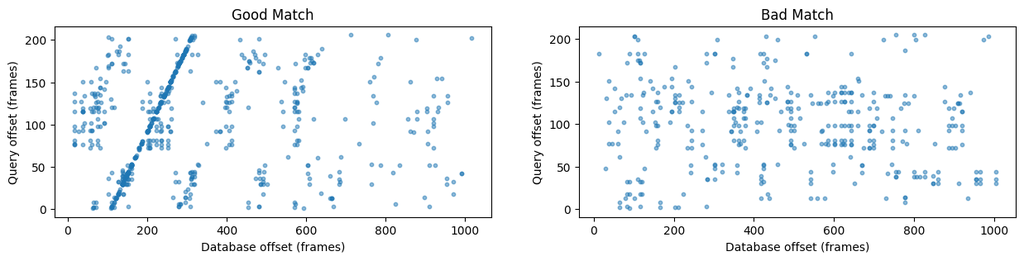

```python
from collections import defaultdict
import matplotlib.pyplot as plt

# Initialize the showcase database
showcase_db = defaultdict(list)
db_offsets_good = []
query_offsets_good = []
db_offsets_bad = []
query_offsets_bad = []

# Add tracks to the showcase database
for track_path in ['tracks/810.low.mp3', 'tracks/712608.low.mp3']:
    for h, track_name, time_offset in compute_hashes_from_spectrogram(track_path):
        showcase_db[h].append((track_name, time_offset))

# Compute query constellation map and find the best match
query_name, query_cmap = compute_constellation_map_single(('queries/810_original.mp3', 11, 3))
best_track, best_delta, best_count, points = find_best_match_for_query(query_name, query_cmap, showcase_db)

# Process points to gather good and bad matches
for anchor in points:
    target_points = get_target_zone_points(
        anchor, points,
        time_min_offset=5, time_max_offset=30,
        freq_min_offset=-15, freq_max_offset=15
    )
    for target_point in target_points:
        h = compute_hash(anchor, target_point)
        if h in showcase_db:
            for (track_name, track_offset) in showcase_db[h]:
                if track_name == best_track:
                    db_offsets_good.append(track_offset)
                    query_offsets_good.append(anchor[1])
                else:
                    db_offsets_bad.append(track_offset)
                    query_offsets_bad.append(anchor[1])

# Plot the results
fig, axes = plt.subplots(1, 2, figsize=(15, 3))

# First subplot: Good matches
axes[0].scatter(db_offsets_good, query_offsets_good, alpha=0.5, s=10)
axes[0].set_xlabel("Database offset (frames)")
axes[0].set_ylabel("Query offset (frames)")
axes[0].set_title("Good Match")

# Second subplot: Bad matches
axes[1].scatter(db_offsets_bad, query_offsets_bad, alpha=0.5, s=10)
axes[1].set_xlabel("Database offset (frames)")
axes[1].set_ylabel("Query offset (frames)")
axes[1].set_title("Bad Match")

plt.show()
```

Similar to the approach described in the original Shazam paper, we compare audio hashes and their corresponding offsets.

- **Left Plot (Good Match)**: The diagonal line in the scatter plot clearly indicates a matching sequence in the track. This pattern signifies that the offsets between the query and database hashes align consistently, suggesting a successful match.
- **Right Plot (Bad Match)**: In contrast, the scatter plot on the right lacks a clear diagonal line, indicating the absence of a matching track. The random distribution of points shows no consistent offset alignment between the query and the database.

This comparison illustrates the difference between a correctly identified track and one that does not match.

## Matching all queries to each database configuration (database size = 60 tarballs - 34000 tracks)

Here, we demonstrate the process of matching all our queries against a database containing 34,000 entries. This showcases the scalability and efficiency of our algorithm when handling large datasets.

```python
s = time.time()
matches_1 = match_queries_with_chunks("queries", **config_1)
e = time.time()
print(e-s)
```

```
Query: queries/1192210_noise.mp3, Track ID: 1192210, Match: True, Time: 1316.7531490325928
Query: queries/91810_coding.mp3, Track ID: 91810, Match: True, Time: 1089.9767875671387
Query: queries/1084710_original.mp3, Track ID: 1084710, Match: True, Time: 3980.3104400634766
Query: queries/242610_mobile.mp3, Track ID: 900733, Match: False, Time: 1049.6950149536133
Query: queries/53310_original.mp3, Track ID: 53310, Match: True, Time: 948.981523513794
Query: queries/1192210_mobile.mp3, Track ID: 1192210, Match: True, Time: 1568.4962272644043
Query: queries/1147910_mobile.mp3, Track ID: 1362117, Match: False, Time: 1077.0132541656494
Query: queries/242610_noise.mp3, Track ID: 242610, Match: True, Time: 1389.7764682769775
Query: queries/152310_mobile.mp3, Track ID: 152310, Match: True, Time: 1940.8535957336426
Query: queries/1227910_original.mp3, Track ID: 1227910, Match: True, Time: 3324.2459297180176
Query: queries/963810_noise.mp3, Track ID: 963810, Match: True, Time: 2838.2205963134766
Query: queries/887210_noise.mp3, Track ID: 887210, Match: True, Time: 1737.8718852996826
Query: queries/91810_noise.mp3, Track ID: 91810, Match: True, Time: 744.365930557251
Query: queries/1084710_coding.mp3, Track ID: 1084710, Match: True, Time: 2843.219518661499
Query: queries/1269810_mobile.mp3, Track ID: 1269810, Match: True, Time: 1454.200029373169
Query: queries/1390710_mobile.mp3, Track ID: 1390710, Match: True, Time: 831.2582969665527
Query: queries/1400510_noise.mp3, Track ID: 153617, Match: False, Time: 2386.037826538086
Query: queries/91810_original.mp3, Track ID: 91810, Match: True, Time: 916.4938926696777
Query: queries/1084710_noise.mp3, Track ID: 1084710, Match: True, Time: 2187.9067420959473
Query: queries/1249910_original.mp3, Track ID: 1249910, Match: True, Time: 1053.4968376159668
Query: queries/1192210_coding.mp3, Track ID: 1192210, Match: True, Time: 655.9484004974365
Query: queries/262010_coding.mp3, Track ID: 262010, Match: True, Time: 1587.4645709991455
Query: queries/262010_original.mp3, Track ID: 262010, Match: True, Time: 1503.7176609039307
Query: queries/1390710_noise.mp3, Track ID: 1390710, Match: True, Time: 689.6648406982422
Query: queries/1147910_original.mp3, Track ID: 1147910, Match: True, Time: 1383.631944656372
Query: queries/219510_noise.mp3, Track ID: 219510, Match: True, Time: 2632.056951522827
Query: queries/136810_coding.mp3, Track ID: 136810, Match: True, Time: 988.7058734893799
Query: queries/1400510_coding.mp3, Track ID: 1400510, Match: True, Time: 587.1145725250244
Query: queries/887210_mobile.mp3, Track ID: 887210, Match: True, Time: 1635.0536346435547
Query: queries/1227910_noise.mp3, Track ID: 1227910, Match: True, Time: 2075.862407684326
Query: queries/119410_mobile.mp3, Track ID: 119410, Match: True, Time: 953.8640975952148
Query: queries/1269810_original.mp3, Track ID: 1269810, Match: True, Time: 3012.6893520355225
Query: queries/53310_noise.mp3, Track ID: 53310, Match: True, Time: 801.9659519195557
Query: queries/136810_mobile.mp3, Track ID: 136304, Match: False, Time: 2646.7413902282715
Query: queries/963810_mobile.mp3, Track ID: 963810, Match: True, Time: 1527.2879600524902
Query: queries/1390710_coding.mp3, Track ID: 1390710, Match: True, Time: 1232.5010299682617
Query: queries/1400510_mobile.mp3, Track ID: 1271442, Match: False, Time: 429.9609661102295
Query: queries/119410_coding.mp3, Track ID: 119410, Match: True, Time: 1058.4039688110352
Query: queries/219510_original.mp3, Track ID: 219510, Match: True, Time: 2291.4516925811768
Query: queries/94710_noise.mp3, Track ID: 94710, Match: True, Time: 2010.3256702423096
```

[output cut: 28 more lines]

```
Query: queries/887210_original.mp3, Track ID: 887210, Match: True, Time: 1471.5194702148438
Query: queries/1084710_mobile.mp3, Track ID: 321050, Match: False, Time: 618.1378364562988
Query: queries/1147910_noise.mp3, Track ID: 1147910, Match: True, Time: 1133.2943439483643
Query: queries/136810_original.mp3, Track ID: 136810, Match: True, Time: 857.1557998657227
Query: queries/887210_coding.mp3, Track ID: 887210, Match: True, Time: 1308.2261085510254
Query: queries/1249910_noise.mp3, Track ID: 1249910, Match: True, Time: 1265.8240795135498
Query: queries/94710_mobile.mp3, Track ID: 94710, Match: True, Time: 1372.138261795044
Query: queries/262010_mobile.mp3, Track ID: 354914, Match: False, Time: 364.9923801422119
Query: queries/242610_original.mp3, Track ID: 242610, Match: True, Time: 1590.9199714660645
Query: queries/136810_noise.mp3, Track ID: 136810, Match: True, Time: 920.4308986663818
Query: queries/1227910_coding.mp3, Track ID: 1227910, Match: True, Time: 2265.1185989379883
Query: queries/963810_coding.mp3, Track ID: 963810, Match: True, Time: 4215.543746948242
Matches: 70/80
Average Time: 1586.78ms
180.46222710609436
```

```python
matches_2 = match_queries_with_chunks("queries", **config_2)
```

```
Query: queries/1192210_noise.mp3, Track ID: 1192210, Match: True, Time: 894.2060470581055
Query: queries/91810_coding.mp3, Track ID: 91810, Match: True, Time: 917.3386096954346
Query: queries/1084710_original.mp3, Track ID: 1084710, Match: True, Time: 2103.229284286499
Query: queries/242610_mobile.mp3, Track ID: 1262645, Match: False, Time: 382.17997550964355
Query: queries/53310_original.mp3, Track ID: 53310, Match: True, Time: 655.4863452911377
Query: queries/1192210_mobile.mp3, Track ID: 1192210, Match: True, Time: 481.8432331085205
Query: queries/1147910_mobile.mp3, Track ID: 173343, Match: False, Time: 475.43931007385254
Query: queries/242610_noise.mp3, Track ID: 242610, Match: True, Time: 1340.8877849578857
Query: queries/152310_mobile.mp3, Track ID: 152310, Match: True, Time: 626.9540786743164
Query: queries/1227910_original.mp3, Track ID: 1227910, Match: True, Time: 2036.5972518920898
Query: queries/963810_noise.mp3, Track ID: 963810, Match: True, Time: 1721.3923931121826
Query: queries/887210_noise.mp3, Track ID: 887210, Match: True, Time: 779.2270183563232
Query: queries/91810_noise.mp3, Track ID: 91810, Match: True, Time: 461.81321144104004
Query: queries/1084710_coding.mp3, Track ID: 1084710, Match: True, Time: 1775.7365703582764
Query: queries/1269810_mobile.mp3, Track ID: 1269810, Match: True, Time: 798.8131046295166
Query: queries/1390710_mobile.mp3, Track ID: 1390710, Match: True, Time: 314.21804428100586
Query: queries/1400510_noise.mp3, Track ID: 1418110, Match: False, Time: 447.9351043701172
Query: queries/91810_original.mp3, Track ID: 91810, Match: True, Time: 407.76681900024414
Query: queries/1084710_noise.mp3, Track ID: 1084710, Match: True, Time: 1296.7495918273926
Query: queries/1249910_original.mp3, Track ID: 1249910, Match: True, Time: 711.4179134368896
Query: queries/1192210_coding.mp3, Track ID: 1192210, Match: True, Time: 399.1734981536865
Query: queries/262010_coding.mp3, Track ID: 262010, Match: True, Time: 893.5372829437256
Query: queries/262010_original.mp3, Track ID: 262010, Match: True, Time: 821.0270404815674
Query: queries/1390710_noise.mp3, Track ID: 1390710, Match: True, Time: 586.1198902130127
Query: queries/1147910_original.mp3, Track ID: 1147910, Match: True, Time: 781.8143367767334
Query: queries/219510_noise.mp3, Track ID: 219510, Match: True, Time: 1712.2762203216553
Query: queries/136810_coding.mp3, Track ID: 136810, Match: True, Time: 590.9163951873779
Query: queries/1400510_coding.mp3, Track ID: 1400510, Match: True, Time: 159.26313400268555
Query: queries/887210_mobile.mp3, Track ID: 887210, Match: True, Time: 808.0523014068604
Query: queries/1227910_noise.mp3, Track ID: 1227910, Match: True, Time: 1198.0104446411133
Query: queries/119410_mobile.mp3, Track ID: 119410, Match: True, Time: 511.11459732055664
Query: queries/1269810_original.mp3, Track ID: 1269810, Match: True, Time: 1786.2558364868164
Query: queries/53310_noise.mp3, Track ID: 53310, Match: True, Time: 488.48724365234375
Query: queries/136810_mobile.mp3, Track ID: 1378007, Match: False, Time: 399.2187976837158
Query: queries/963810_mobile.mp3, Track ID: 963810, Match: True, Time: 911.7326736450195
Query: queries/1390710_coding.mp3, Track ID: 1390710, Match: True, Time: 463.6094570159912
Query: queries/1400510_mobile.mp3, Track ID: 1271442, Match: False, Time: 229.68721389770508
Query: queries/119410_coding.mp3, Track ID: 119410, Match: True, Time: 797.2171306610107
Query: queries/219510_original.mp3, Track ID: 219510, Match: True, Time: 1684.8971843719482
Query: queries/94710_noise.mp3, Track ID: 94710, Match: True, Time: 1017.8167819976807
```

[output cut: 27 more lines]

```
Query: queries/119410_noise.mp3, Track ID: 119410, Match: True, Time: 618.0951595306396
Query: queries/887210_original.mp3, Track ID: 887210, Match: True, Time: 986.7887496948242
Query: queries/1084710_mobile.mp3, Track ID: 1310246, Match: False, Time: 170.98617553710938
Query: queries/1147910_noise.mp3, Track ID: 1147910, Match: True, Time: 681.5440654754639
Query: queries/136810_original.mp3, Track ID: 136810, Match: True, Time: 514.946460723877
Query: queries/887210_coding.mp3, Track ID: 887210, Match: True, Time: 657.6142311096191
Query: queries/1249910_noise.mp3, Track ID: 1249910, Match: True, Time: 838.7539386749268
Query: queries/94710_mobile.mp3, Track ID: 13910, Match: False, Time: 753.0546188354492
Query: queries/262010_mobile.mp3, Track ID: 1368401, Match: False, Time: 333.79149436950684
Query: queries/242610_original.mp3, Track ID: 242610, Match: True, Time: 1034.9819660186768
Query: queries/136810_noise.mp3, Track ID: 136810, Match: True, Time: 553.5571575164795
Query: queries/1227910_coding.mp3, Track ID: 1227910, Match: True, Time: 1225.1484394073486
Query: queries/963810_coding.mp3, Track ID: 963810, Match: True, Time: 1218.4326648712158
Matches: 69/80
Average Time: 894.15ms
```

```python
matches_3 = match_queries_with_chunks("queries", **config_3)
```

```
Query: queries/1192210_noise.mp3, Track ID: 1192210, Match: True, Time: 1158.4198474884033
Query: queries/91810_coding.mp3, Track ID: 91810, Match: True, Time: 969.0625667572021
Query: queries/1084710_original.mp3, Track ID: 1084710, Match: True, Time: 1976.7858982086182
Query: queries/242610_mobile.mp3, Track ID: 1352901, Match: False, Time: 734.5805168151855
Query: queries/53310_original.mp3, Track ID: 53310, Match: True, Time: 637.1164321899414
Query: queries/1192210_mobile.mp3, Track ID: 1192210, Match: True, Time: 961.0590934753418
Query: queries/1147910_mobile.mp3, Track ID: 1066916, Match: False, Time: 856.6498756408691
Query: queries/242610_noise.mp3, Track ID: 242610, Match: True, Time: 1467.466115951538
Query: queries/152310_mobile.mp3, Track ID: 152310, Match: True, Time: 1127.9003620147705
Query: queries/1227910_original.mp3, Track ID: 1227910, Match: True, Time: 2094.0284729003906
Query: queries/963810_noise.mp3, Track ID: 963810, Match: True, Time: 1690.73486328125
Query: queries/887210_noise.mp3, Track ID: 887210, Match: True, Time: 948.2851028442383
Query: queries/91810_noise.mp3, Track ID: 91810, Match: True, Time: 482.8166961669922
Query: queries/1084710_coding.mp3, Track ID: 1084710, Match: True, Time: 1830.9903144836426
Query: queries/1269810_mobile.mp3, Track ID: 1269810, Match: True, Time: 953.6447525024414
Query: queries/1390710_mobile.mp3, Track ID: 1390710, Match: True, Time: 336.5476131439209
Query: queries/1400510_noise.mp3, Track ID: 1146535, Match: False, Time: 287.63484954833984
Query: queries/91810_original.mp3, Track ID: 91810, Match: True, Time: 412.59264945983887
Query: queries/1084710_noise.mp3, Track ID: 1084710, Match: True, Time: 1413.914442062378
Query: queries/1249910_original.mp3, Track ID: 1249910, Match: True, Time: 1133.0430507659912
Query: queries/1192210_coding.mp3, Track ID: 1192210, Match: True, Time: 435.11962890625
Query: queries/262010_coding.mp3, Track ID: 262010, Match: True, Time: 1235.1701259613037
Query: queries/262010_original.mp3, Track ID: 262010, Match: True, Time: 934.9167346954346
Query: queries/1390710_noise.mp3, Track ID: 1390710, Match: True, Time: 464.27011489868164
Query: queries/1147910_original.mp3, Track ID: 1147910, Match: True, Time: 614.2761707305908
Query: queries/219510_noise.mp3, Track ID: 219510, Match: True, Time: 1470.9548950195312
Query: queries/136810_coding.mp3, Track ID: 136810, Match: True, Time: 807.6047897338867
Query: queries/1400510_coding.mp3, Track ID: 1400510, Match: True, Time: 178.15804481506348
Query: queries/887210_mobile.mp3, Track ID: 887210, Match: True, Time: 1000.44846534729
Query: queries/1227910_noise.mp3, Track ID: 1227910, Match: True, Time: 1499.9308586120605
Query: queries/119410_mobile.mp3, Track ID: 119410, Match: True, Time: 391.6041851043701
Query: queries/1269810_original.mp3, Track ID: 1269810, Match: True, Time: 1846.6675281524658
Query: queries/53310_noise.mp3, Track ID: 53310, Match: True, Time: 520.0550556182861
Query: queries/136810_mobile.mp3, Track ID: 1065626, Match: False, Time: 387.1767520904541
Query: queries/963810_mobile.mp3, Track ID: 963810, Match: True, Time: 1039.933681488037
Query: queries/1390710_coding.mp3, Track ID: 1390710, Match: True, Time: 537.6236438751221
Query: queries/1400510_mobile.mp3, Track ID: 1271442, Match: False, Time: 485.60595512390137
Query: queries/119410_coding.mp3, Track ID: 119410, Match: True, Time: 959.1410160064697
Query: queries/219510_original.mp3, Track ID: 219510, Match: True, Time: 1159.0852737426758
Query: queries/94710_noise.mp3, Track ID: 94710, Match: True, Time: 1231.5387725830078
```

[output cut: 27 more lines]

```
Query: queries/119410_noise.mp3, Track ID: 119410, Match: True, Time: 692.3913955688477
Query: queries/887210_original.mp3, Track ID: 887210, Match: True, Time: 3090.308904647827
Query: queries/1084710_mobile.mp3, Track ID: 1356534, Match: False, Time: 414.68071937561035
Query: queries/1147910_noise.mp3, Track ID: 1147910, Match: True, Time: 681.0586452484131
Query: queries/136810_original.mp3, Track ID: 136810, Match: True, Time: 463.7434482574463
Query: queries/887210_coding.mp3, Track ID: 887210, Match: True, Time: 821.4073181152344
Query: queries/1249910_noise.mp3, Track ID: 1249910, Match: True, Time: 752.4545192718506
Query: queries/94710_mobile.mp3, Track ID: 94710, Match: True, Time: 868.0164813995361
Query: queries/262010_mobile.mp3, Track ID: 208032, Match: False, Time: 235.3668212890625
Query: queries/242610_original.mp3, Track ID: 242610, Match: True, Time: 844.1300392150879
Query: queries/136810_noise.mp3, Track ID: 136810, Match: True, Time: 511.7623805999756
Query: queries/1227910_coding.mp3, Track ID: 1227910, Match: True, Time: 1554.9097061157227
Query: queries/963810_coding.mp3, Track ID: 963810, Match: True, Time: 1408.7259769439697
Matches: 71/80
Average Time: 994.50ms
```

```python
matches_4 = match_queries_with_chunks("queries", **config_4)
```

```
Query: queries/1192210_noise.mp3, Track ID: 1192210, Match: True, Time: 1898.7758159637451
Query: queries/91810_coding.mp3, Track ID: 91810, Match: True, Time: 1064.7180080413818
Query: queries/1084710_original.mp3, Track ID: 1084710, Match: True, Time: 2792.884588241577
Query: queries/242610_mobile.mp3, Track ID: 196550, Match: False, Time: 1582.0128917694092
Query: queries/53310_original.mp3, Track ID: 53310, Match: True, Time: 906.5184593200684
Query: queries/1192210_mobile.mp3, Track ID: 1192210, Match: True, Time: 569.2613124847412
Query: queries/1147910_mobile.mp3, Track ID: 1066916, Match: False, Time: 1292.2487258911133
Query: queries/242610_noise.mp3, Track ID: 242610, Match: True, Time: 1894.3397998809814
Query: queries/152310_mobile.mp3, Track ID: 152310, Match: True, Time: 1280.3421020507812
Query: queries/1227910_original.mp3, Track ID: 1227910, Match: True, Time: 2690.7365322113037
Query: queries/963810_noise.mp3, Track ID: 963810, Match: True, Time: 2241.7099475860596
Query: queries/887210_noise.mp3, Track ID: 887210, Match: True, Time: 1686.143398284912
Query: queries/91810_noise.mp3, Track ID: 91810, Match: True, Time: 569.7338581085205
Query: queries/1084710_coding.mp3, Track ID: 1084710, Match: True, Time: 2439.4924640655518
Query: queries/1269810_mobile.mp3, Track ID: 1269810, Match: True, Time: 1263.5669708251953
Query: queries/1390710_mobile.mp3, Track ID: 1390710, Match: True, Time: 469.3448543548584
Query: queries/1400510_noise.mp3, Track ID: 1146535, Match: False, Time: 721.1077213287354
Query: queries/91810_original.mp3, Track ID: 91810, Match: True, Time: 474.83015060424805
Query: queries/1084710_noise.mp3, Track ID: 1084710, Match: True, Time: 2102.3497581481934
Query: queries/1249910_original.mp3, Track ID: 1249910, Match: True, Time: 872.298002243042
Query: queries/1192210_coding.mp3, Track ID: 1192210, Match: True, Time: 888.4994983673096
Query: queries/262010_coding.mp3, Track ID: 262010, Match: True, Time: 1641.9291496276855
Query: queries/262010_original.mp3, Track ID: 262010, Match: True, Time: 3270.193338394165
Query: queries/1390710_noise.mp3, Track ID: 1390710, Match: True, Time: 648.5309600830078
Query: queries/1147910_original.mp3, Track ID: 1147910, Match: True, Time: 935.0168704986572
Query: queries/219510_noise.mp3, Track ID: 219510, Match: True, Time: 2163.198947906494
Query: queries/136810_coding.mp3, Track ID: 136810, Match: True, Time: 811.0177516937256
Query: queries/1400510_coding.mp3, Track ID: 1400510, Match: True, Time: 237.4553680419922
Query: queries/887210_mobile.mp3, Track ID: 887210, Match: True, Time: 1350.2089977264404
Query: queries/1227910_noise.mp3, Track ID: 1227910, Match: True, Time: 1745.7869052886963
Query: queries/119410_mobile.mp3, Track ID: 119410, Match: True, Time: 545.4599857330322
Query: queries/1269810_original.mp3, Track ID: 1269810, Match: True, Time: 2850.6033420562744
Query: queries/53310_noise.mp3, Track ID: 53310, Match: True, Time: 970.5171585083008
Query: queries/136810_mobile.mp3, Track ID: 614516, Match: False, Time: 552.0918369293213
Query: queries/963810_mobile.mp3, Track ID: 963810, Match: True, Time: 1478.2977104187012
Query: queries/1390710_coding.mp3, Track ID: 1390710, Match: True, Time: 755.9590339660645
Query: queries/1400510_mobile.mp3, Track ID: 1271442, Match: False, Time: 354.2811870574951
Query: queries/119410_coding.mp3, Track ID: 119410, Match: True, Time: 860.7356548309326
Query: queries/219510_original.mp3, Track ID: 219510, Match: True, Time: 1703.9947509765625
Query: queries/94710_noise.mp3, Track ID: 94710, Match: True, Time: 1250.7035732269287
```

[output cut: 27 more lines]

```
Query: queries/119410_noise.mp3, Track ID: 119410, Match: True, Time: 2783.6663722991943
Query: queries/887210_original.mp3, Track ID: 887210, Match: True, Time: 1277.2047519683838
Query: queries/1084710_mobile.mp3, Track ID: 1356534, Match: False, Time: 275.8371829986572
Query: queries/1147910_noise.mp3, Track ID: 1147910, Match: True, Time: 993.0267333984375
Query: queries/136810_original.mp3, Track ID: 136810, Match: True, Time: 974.7738838195801
Query: queries/887210_coding.mp3, Track ID: 887210, Match: True, Time: 1126.3165473937988
Query: queries/1249910_noise.mp3, Track ID: 1249910, Match: True, Time: 1293.133020401001
Query: queries/94710_mobile.mp3, Track ID: 1351224, Match: False, Time: 1150.7301330566406
Query: queries/262010_mobile.mp3, Track ID: 354914, Match: False, Time: 318.8948631286621
Query: queries/242610_original.mp3, Track ID: 242610, Match: True, Time: 1576.4405727386475
Query: queries/136810_noise.mp3, Track ID: 136810, Match: True, Time: 712.0327949523926
Query: queries/1227910_coding.mp3, Track ID: 1227910, Match: True, Time: 1711.8861675262451
Query: queries/963810_coding.mp3, Track ID: 963810, Match: True, Time: 1896.1155414581299
Matches: 70/80
Average Time: 1330.65ms
```

# Task 4: Evaluation and Report

In this section, we evaluate we compare and visualize our experiments. We evaluate our experiments on various metrics and also show the results visually. Finally, we also summarize our findings and thought process.

## Time for building each database

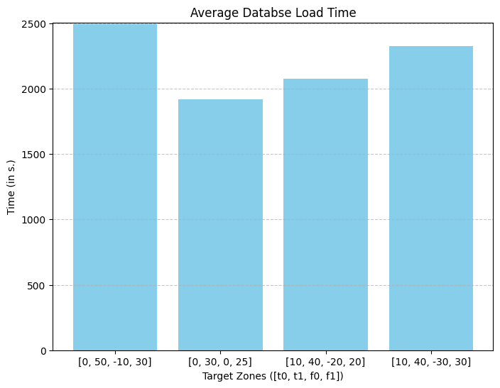

```python
import matplotlib.pyplot as plt

# Values to plot
labels = [(f'[{config["time_min_offset"]}, {config["time_max_offset"]}, {config["freq_min_offset"]}, {config["freq_max_offset"]}]') for config in configs]

times = [0, 0, 0, 0]

times[0] += delta1
times[1] += delta2
times[2] += delta3
times[3] += delta4


# Creating the bar plot
plt.figure(figsize=(8, 6))
plt.bar(labels, times, color='skyblue')
plt.title('Average Databse Load Time')
plt.xlabel('Target Zones ([t0, t1, f0, f1])')
plt.ylabel('Time (in s.)')
plt.ylim(0, max(times) + 10)
plt.grid(axis='y', linestyle='--', alpha=0.7)

# Display the plot
plt.show()
```

The bar chart depicts the average database load time for different target zone configurations. The configuration [0, 50, -10, 30] has the highest load time, followed closely by [10, 40, -30, 30]. The configuration [0, 30, 0, 25] demonstrates the shortest load time, while [10, 40, -20, 20] shows a moderate load time.

## Query time comparison

```python
# for evaluation
queries = load_filenames('queries')
```

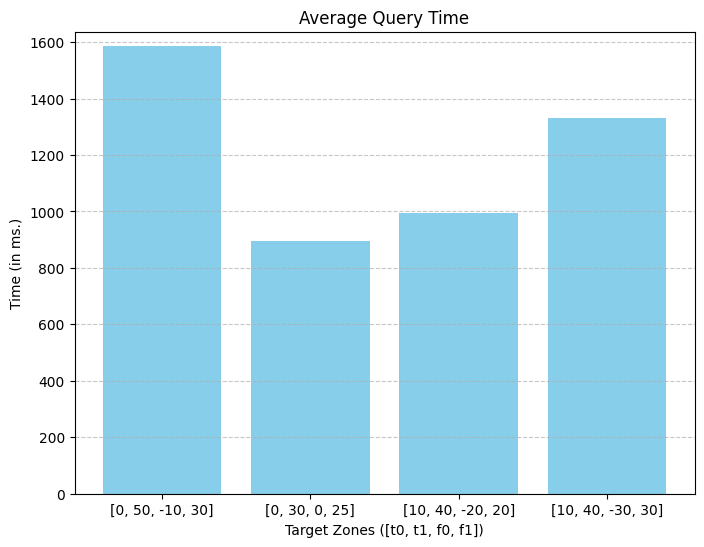

```python
import matplotlib.pyplot as plt

# Values to plot
labels = [(f'[{config["time_min_offset"]}, {config["time_max_offset"]}, {config["freq_min_offset"]}, {config["freq_max_offset"]}]') for config in configs]

times = [0, 0, 0, 0]

for query_name in queries:
    times[0] += matches_1[query_name][4]
    times[1] += matches_2[query_name][4]
    times[2] += matches_3[query_name][4]
    times[3] += matches_4[query_name][4]

times[0] /= len(queries)
times[1] /= len(queries)
times[2] /= len(queries)
times[3] /= len(queries)


# Creating the bar plot
plt.figure(figsize=(8, 6))
plt.bar(labels, times, color='skyblue')
plt.title('Average Query Time')
plt.xlabel('Target Zones ([t0, t1, f0, f1])')
plt.ylabel('Time (in ms.)')
plt.ylim(0, max(times) + 50)
plt.grid(axis='y', linestyle='--', alpha=0.7)

# Display the plot
plt.show()
```

This figure illustrates the average query time required to find a match for each configuration of target zones. The configurations are presented on the x-axis, while the y-axis represents the average query time in milliseconds.

Thanks to our fingerprint hashing method combined with the chunk-based database approach, we achieve efficient average query times. Compared to our previous sliding constellation map method, the fingerprinting approach is significantly more efficient and demonstrates much better scalability, making it well-suited for larger datasets and real-world applications.

## Matching Accuracy Comparison

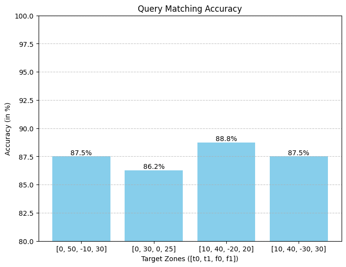

```python
import matplotlib.pyplot as plt

get_accuracy(queries, matches_1)["total"]
accuracies = [get_accuracy(queries, matches_1)["total"], get_accuracy(queries, matches_2)["total"], get_accuracy(queries, matches_3)["total"], get_accuracy(queries, matches_4)["total"]]

# Values to plot
labels = [(f'[{config["time_min_offset"]}, {config["time_max_offset"]}, {config["freq_min_offset"]}, {config["freq_max_offset"]}]') for config in configs]
values = [ac*100 for ac in accuracies]


# Creating the bar plot
plt.figure(figsize=(8, 6))
bars = plt.bar(labels, values, color='skyblue')

# Adding percentages above the bars
for bar, value in zip(bars, values):
    plt.text(bar.get_x() + bar.get_width() / 2, bar.get_height() + 0.02,
             f'{value:.1f}%', ha='center', va='bottom', fontsize=10)

# Adding title and labels
plt.title('Query Matching Accuracy')
plt.xlabel('Target Zones ([t0, t1, f0, f1])')
plt.ylabel('Accuracy (in %)')
plt.ylim(80, 100)  # Leave some space above the bars for annotations
plt.grid(axis='y', linestyle='--', alpha=0.7)

# Display the plot
plt.show()
```

The bar chart illustrates the query matching accuracy across various target zone configurations. The configuration [10, 40, -20, 20] stands out with the highest accuracy of 88.8%, while [0, 30, 0, 25] records the lowest accuracy at 86.2%. Both [0, 50, -10, 30] and [10, 40, -30, 30] achieve a similar accuracy of 87.5%. The target zones were selected through a trial-and-error approach, where we tested different configurations on smaller sets of tracks to identify the most suitable setups. This chart highlights how different target zone configurations influence query matching performance.

## Category Comparison

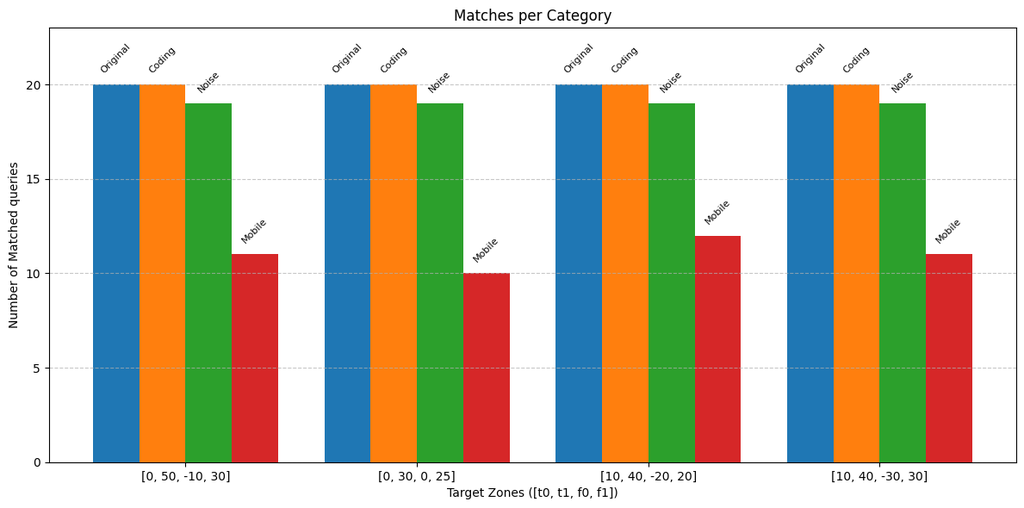

```python
# Configuration names and corresponding counts for each category
labels = [(f'[{config["time_min_offset"]}, {config["time_max_offset"]}, {config["freq_min_offset"]}, {config["freq_max_offset"]}]') for config in configs]


matched_original = [get_accuracy(queries, matches_1)['original']*20, get_accuracy(queries, matches_2)['original']*20, get_accuracy(queries, matches_3)['original']*20, get_accuracy(queries, matches_4)['original']*20]
matched_noise = [get_accuracy(queries, matches_1)['noise']*20, get_accuracy(queries, matches_2)['noise']*20, get_accuracy(queries, matches_3)['noise']*20, get_accuracy(queries, matches_4)['noise']*20]
matched_coding = [get_accuracy(queries, matches_1)['coding']*20, get_accuracy(queries, matches_2)['coding']*20, get_accuracy(queries, matches_3)['coding']*20, get_accuracy(queries, matches_4)['coding']*20]
matched_mobile = [get_accuracy(queries, matches_1)['mobile']*20, get_accuracy(queries, matches_2)['mobile']*20, get_accuracy(queries, matches_3)['mobile']*20, get_accuracy(queries, matches_4)['mobile']*20]



# Number of configurations
num_configs = len(labels)

# X positions for groups of bars
x = np.arange(num_configs)

# Width of each bar
bar_width = 0.2

# Categories and their data
categories = ['Original', 'Coding', 'Noise', 'Mobile']
data = [matched_original, matched_coding, matched_noise, matched_mobile]

# Plot
plt.figure(figsize=(12, 6))

for i, category_data in enumerate(data):
    # Offset for each bar in a group
    bar_positions = x + (i - 1.5) * bar_width
    bars = plt.bar(bar_positions, category_data, width=bar_width)

    # Add category labels on top of each bar
    for bar in bars:
        plt.text(bar.get_x() + bar.get_width() / 2, bar.get_height() + 0.5,  # Adjusted offset for more space
                 categories[i], ha='center', va='bottom', rotation=45, fontsize=8)

# Add labels, title, and legend
plt.xlabel('Target Zones ([t0, t1, f0, f1])')
plt.ylabel('Number of Matched queries')
plt.title('Matches per Category')
plt.xticks(x, labels)

# Adjust the y-axis to leave more space at the top
plt.ylim(0, max(max(matched_original), max(matched_coding), max(matched_noise), max(matched_mobile)) + 3)

# Show grid and plot
plt.grid(axis='y', linestyle='--', alpha=0.7)
plt.tight_layout()
plt.show()
```

Notably, mobile queries remain particularly challenging to match, likely due to excessive background noise rendering the track nearly inaudible.

The figure provides valuable insights into where the most significant errors occur in query matching. Queries extracted directly from the original track, without any modifications, consistently achieve perfect matches. Similarly, queries that involve coding modifications maintain 100% accuracy.

However, queries with artificially added noise show a slight decline in performance, as they are matched less reliably. The most substantial drop in accuracy is observed in mobile queries, where some configurations achieve only slightly above 50% accuracy.

This analysis underscores the difficulties posed by noisy environments and mobile-modified queries, emphasizing the need for further optimization to handle these scenarios effectively

## Hash Generation Comparison

```python
import pandas as pd

dist_freq = 11
dist_time = 3
num_tracks = 34076

# Prepare data for the table
rows = []
for i, config in enumerate(configs):
    config_name = f'hash_count_freq11_time3_min{config["time_min_offset"]}_max{config["time_max_offset"]}_{config["freq_min_offset"]}_{config["freq_max_offset"]}'
    label = f"[{config['time_min_offset']}, {config['time_max_offset']}, {config['freq_min_offset']}, {config['freq_max_offset']}]"
    file_path = f"partial_database_{dist_freq}#{dist_time}#{config['time_min_offset']}#{config['time_max_offset']}#{config['freq_min_offset']}#{config['freq_max_offset']}.pkl"
    hash_value = hash_count.get(config_name, 0)

    # Get the file size in MB
    file_size_mb = os.path.getsize(file_path) / (1024 ** 2) if os.path.exists(file_path) else "File not found"

    # Calculate number of hashes per track
    hashes_per_track = hash_value / num_tracks if num_tracks > 0 else "N/A"

    rows.append({
        "Configuration": label,
        "Number of Hashes": hash_value,
        "Hashes per Track": round(hashes_per_track) if isinstance(hashes_per_track, (int, float)) else hashes_per_track,
        "Storage (MB)": round(file_size_mb, 2) if isinstance(file_size_mb, (int, float)) else file_size_mb
    })

# Create a DataFrame
hash_table = pd.DataFrame(rows)
hash_table.index = ["" for _ in range(len(hash_table))]  # Remove index

# Display the table
hash_table
#tabelle
```

|  | Configuration | Number of Hashes | Hashes per Track | Storage (MB) |
| --- | --- | --- | --- | --- |
|  | [0, 50, -10, 30] | 385540600 | 11314 | 1836.52 |
|  | [0, 30, 0, 25] | 163487158 | 4798 | 776.33 |
|  | [10, 40, -20, 20] | 244521884 | 7176 | 1165.99 |
|  | [10, 40, -30, 30] | 344617504 | 10113 | 1643.57 |

The table presents the hash generation results for different configurations, showing the number of hashes generated, hashes per track, and the corresponding storage usage in megabytes. Larger target zones result in significantly higher hash counts, with the largest configuration producing 385.5 million hashes and requiring 1836 MB of storage. Additionally, during the notebook execution, hash generation consumed up to 5 GB of RAM and utilized as much as 5.5 GB of disk storage.

## Average Hash Generation Per Track

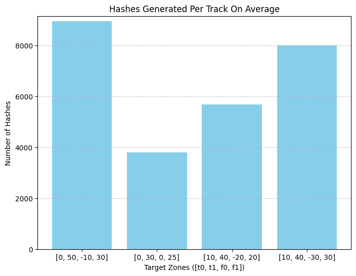

```python
# Values to plot

config_names = [
    f'hash_count_freq11_time3_min{config["time_min_offset"]}_max{config["time_max_offset"]}_{config["freq_min_offset"]}_{config["freq_max_offset"]}'
    for config in configs
]

num_tracks = 43076

hashes = [0, 0, 0, 0]

hashes[0] += hash_count[config_names[0]]/num_tracks
hashes[1] += hash_count[config_names[1]]/num_tracks
hashes[2] += hash_count[config_names[2]]/num_tracks
hashes[3] += hash_count[config_names[3]]/num_tracks


# Creating the bar plot
plt.figure(figsize=(8, 6))
plt.bar(labels, hashes, color='skyblue')
plt.title('Hashes Generated Per Track On Average')
plt.xlabel('Target Zones ([t0, t1, f0, f1])')
plt.ylabel('Number of Hashes')
plt.ylim(0, max(hashes) + 200)
plt.grid(axis='y', linestyle='--', alpha=0.7)

# Display the plot
plt.show()
#hashes pro tracks on average
```

The bar chart displays the average number of hashes generated per track across various target zone configurations. The configuration [0, 50, -10, 30] generates the highest average number of hashes per track, while [0, 30, 0, 25] generates the fewest. The target zone [10, 40, -30, 30] produces the second-highest number of hashes. Meanwhile, the configuration [10, 40, -20, 20] generates a moderate number of hashes but achieves the highest matching performance. These results underscore the impact of different target zone settings on the hashing process